# 2a Overview For Coders

Asher Baer

### Overview

The goal of this document is to give a quick-start with more detail for people experienced in CS. Meaing C++, C#, or whatever else.

#### Variable

Declare a variable by typing anything without quotes.Must not start with a number.  
Must either give it a blank object or simply have an object you want to put into it.  
Use either = or <-

By default, everything will be in the global scope (unless declared in a function).

```r
##Examples
babys_first_variable.periods_mean_nothing = 2
print(babys_first_variable.periods_mean_nothing + 2)
```

```
## [1] 4
```

```r
x = babys_first_variable.periods_mean_nothing + 2
print(x + babys_first_variable.periods_mean_nothing)
```

```
## [1] 6
```

```r
rm(x)
```

### Types?

R is functional, but objects can have types. There are a few main ones, that will be familiar and obvious.  
1. Integer  
2. Double (like a float)  
3. Character (not just a single character, it’s a string in other languages)  
4. Factor (basically an enum)  
5. logical (boolean)  
6. Others not useful for now(Raw/Complex types)

```r
x = as.integer(1)
typeof(x)
```

```
## [1] "integer"
```

```r
x = 1.5
typeof(x)
```

```
## [1] "double"
```

```r
typeof(TRUE)
```

```
## [1] "logical"
```

### Lists

to make a list, put it inside a c() so, c(1,2,3) is a list of 3 elements.

indexing starts at 1!

```r
x = c("hi", "there")
x[1]
```

```
## [1] "hi"
```

```r
x[2]
```

```
## [1] "there"
```

```r
x[3]
```

```
## [1] NA
```

```r
x[4] = 12
print(x)
```

```
## [1] "hi"    "there" NA      "12"
```

### Dataframes

This will be your bread and butter doing data-science in R.  
A dataframe is effectively a matrix, spreadsheet, or series of columns put together.  
Each column can have it’s own type. Let’s look at one of the default ones.

```r
print(mtcars)
```

```
##                      mpg cyl  disp  hp drat    wt  qsec vs am gear carb
## Mazda RX4           21.0   6 160.0 110 3.90 2.620 16.46  0  1    4    4
## Mazda RX4 Wag       21.0   6 160.0 110 3.90 2.875 17.02  0  1    4    4
## Datsun 710          22.8   4 108.0  93 3.85 2.320 18.61  1  1    4    1
## Hornet 4 Drive      21.4   6 258.0 110 3.08 3.215 19.44  1  0    3    1
## Hornet Sportabout   18.7   8 360.0 175 3.15 3.440 17.02  0  0    3    2
## Valiant             18.1   6 225.0 105 2.76 3.460 20.22  1  0    3    1
## Duster 360          14.3   8 360.0 245 3.21 3.570 15.84  0  0    3    4
## Merc 240D           24.4   4 146.7  62 3.69 3.190 20.00  1  0    4    2
## Merc 230            22.8   4 140.8  95 3.92 3.150 22.90  1  0    4    2
## Merc 280            19.2   6 167.6 123 3.92 3.440 18.30  1  0    4    4
## Merc 280C           17.8   6 167.6 123 3.92 3.440 18.90  1  0    4    4
## Merc 450SE          16.4   8 275.8 180 3.07 4.070 17.40  0  0    3    3
## Merc 450SL          17.3   8 275.8 180 3.07 3.730 17.60  0  0    3    3
## Merc 450SLC         15.2   8 275.8 180 3.07 3.780 18.00  0  0    3    3
## Cadillac Fleetwood  10.4   8 472.0 205 2.93 5.250 17.98  0  0    3    4
## Lincoln Continental 10.4   8 460.0 215 3.00 5.424 17.82  0  0    3    4
## Chrysler Imperial   14.7   8 440.0 230 3.23 5.345 17.42  0  0    3    4
## Fiat 128            32.4   4  78.7  66 4.08 2.200 19.47  1  1    4    1
## Honda Civic         30.4   4  75.7  52 4.93 1.615 18.52  1  1    4    2
## Toyota Corolla      33.9   4  71.1  65 4.22 1.835 19.90  1  1    4    1
## Toyota Corona       21.5   4 120.1  97 3.70 2.465 20.01  1  0    3    1
## Dodge Challenger    15.5   8 318.0 150 2.76 3.520 16.87  0  0    3    2
## AMC Javelin         15.2   8 304.0 150 3.15 3.435 17.30  0  0    3    2
## Camaro Z28          13.3   8 350.0 245 3.73 3.840 15.41  0  0    3    4
## Pontiac Firebird    19.2   8 400.0 175 3.08 3.845 17.05  0  0    3    2
## Fiat X1-9           27.3   4  79.0  66 4.08 1.935 18.90  1  1    4    1
## Porsche 914-2       26.0   4 120.3  91 4.43 2.140 16.70  0  1    5    2
## Lotus Europa        30.4   4  95.1 113 3.77 1.513 16.90  1  1    5    2
## Ford Pantera L      15.8   8 351.0 264 4.22 3.170 14.50  0  1    5    4
## Ferrari Dino        19.7   6 145.0 175 3.62 2.770 15.50  0  1    5    6
## Maserati Bora       15.0   8 301.0 335 3.54 3.570 14.60  0  1    5    8
## Volvo 142E          21.4   4 121.0 109 4.11 2.780 18.60  1  1    4    2
```

We can treat dataframes as objects and save them in variables. In fact, much of the data-cleaning process will be done by doing something to a data-frame, then saving the output in a variable.

We can index a dataframe

```r
row_index = 3
column_index = 2

print(mtcars[row_index, column_index])
```

```
## [1] 4
```

```r
## we can get the column as a list easily
print(mtcars[, column_index])
```

```
##  [1] 6 6 4 6 8 6 8 4 4 6 6 8 8 8 8 8 8 4 4 4 4 8 8 8 8 4 4 4 8 6 8 4
```

```r
#or the row as a 1 x ncol data-frame
print(mtcars[row_index, ])
```

```
##             mpg cyl disp hp drat   wt  qsec vs am gear carb
## Datsun 710 22.8   4  108 93 3.85 2.32 18.61  1  1    4    1
```

### Functions

functions are defined with “function()” then list the input variables. Return values with “return()”

```r
#
function_whatever_name <- function(input_whatever_var){
  print(input_whatever_var)
  if(is.numeric(input_whatever_var)){print("I'm a numeric too!")
    }
  return(input_whatever_var)
}

function_whatever_name(2)
```

```
## [1] 2
## [1] "I'm a numeric too!"
```

```
## [1] 2
```

# Now let’s get started

### To the point

This has been a useful starting point looking at base R. However, much is done using a great package called the tidyverse.

#### Install

To install a package in R, go over to the bottom right panel, click “packages”, then “install”, then type in “dplyr”

To load a package, type in library(package_name).It will be loaded globally, and gie some conflict warnings.

```r
library(dplyr)
```

To call a function from a package, you can specific it using package::function

```r
#select takes a dataframe, then keeps some of the columns you selected
dplyr::select(mtcars,1)
```

```
##                      mpg
## Mazda RX4           21.0
## Mazda RX4 Wag       21.0
## Datsun 710          22.8
## Hornet 4 Drive      21.4
## Hornet Sportabout   18.7
## Valiant             18.1
## Duster 360          14.3
## Merc 240D           24.4
## Merc 230            22.8
## Merc 280            19.2
## Merc 280C           17.8
## Merc 450SE          16.4
## Merc 450SL          17.3
## Merc 450SLC         15.2
## Cadillac Fleetwood  10.4
## Lincoln Continental 10.4
## Chrysler Imperial   14.7
## Fiat 128            32.4
## Honda Civic         30.4
## Toyota Corolla      33.9
## Toyota Corona       21.5
## Dodge Challenger    15.5
## AMC Javelin         15.2
## Camaro Z28          13.3
## Pontiac Firebird    19.2
## Fiat X1-9           27.3
## Porsche 914-2       26.0
## Lotus Europa        30.4
## Ford Pantera L      15.8
## Ferrari Dino        19.7
## Maserati Bora       15.0
## Volvo 142E          21.4
```

### Pipes

The last fundamental thing to really know is the pipe operator. Written as %>%, it can be read as “and then”  
Basically, it take the output of the last function and uses it as the input for the next. If you want to specify where as an argument it should be used, technically it can be done with the period, .

```r
mtcars %>% dplyr::select(1)
```

```
##                      mpg
## Mazda RX4           21.0
## Mazda RX4 Wag       21.0
## Datsun 710          22.8
## Hornet 4 Drive      21.4
## Hornet Sportabout   18.7
## Valiant             18.1
## Duster 360          14.3
## Merc 240D           24.4
## Merc 230            22.8
## Merc 280            19.2
## Merc 280C           17.8
## Merc 450SE          16.4
## Merc 450SL          17.3
## Merc 450SLC         15.2
## Cadillac Fleetwood  10.4
## Lincoln Continental 10.4
## Chrysler Imperial   14.7
## Fiat 128            32.4
## Honda Civic         30.4
## Toyota Corolla      33.9
## Toyota Corona       21.5
## Dodge Challenger    15.5
## AMC Javelin         15.2
## Camaro Z28          13.3
## Pontiac Firebird    19.2
## Fiat X1-9           27.3
## Porsche 914-2       26.0
## Lotus Europa        30.4
## Ford Pantera L      15.8
## Ferrari Dino        19.7
## Maserati Bora       15.0
## Volvo 142E          21.4
```

```r
mtcars %>% dplyr::select(.,1)
```

```
##                      mpg
## Mazda RX4           21.0
## Mazda RX4 Wag       21.0
## Datsun 710          22.8
## Hornet 4 Drive      21.4
## Hornet Sportabout   18.7
## Valiant             18.1
## Duster 360          14.3
## Merc 240D           24.4
## Merc 230            22.8
## Merc 280            19.2
## Merc 280C           17.8
## Merc 450SE          16.4
## Merc 450SL          17.3
## Merc 450SLC         15.2
## Cadillac Fleetwood  10.4
## Lincoln Continental 10.4
## Chrysler Imperial   14.7
## Fiat 128            32.4
## Honda Civic         30.4
## Toyota Corolla      33.9
## Toyota Corona       21.5
## Dodge Challenger    15.5
## AMC Javelin         15.2
## Camaro Z28          13.3
## Pontiac Firebird    19.2
## Fiat X1-9           27.3
## Porsche 914-2       26.0
## Lotus Europa        30.4
## Ford Pantera L      15.8
## Ferrari Dino        19.7
## Maserati Bora       15.0
## Volvo 142E          21.4
```

### Some dplyr bread and butter functions

We want to manipulate dataframes since it is our way of storing data, interacting with it, and doing things at scale.  
Below are some key functions I use a lot.  
1. dplyr::mutate – changes the column or creates a new one if that rows is not there  
2. dplyr::case_when – if else but can be used in mutate  
3. dplyr::filter – used to keep rows based on a condition (needs a logical)  
4. dplyr::select – keeps columns, based on names  
5. dplyr::full_join or dplyr::left_join – joins two dataframes together  
6. dplyr::summarize – lets you do operations across all rows. any function, even user defined 7. dplyr::group_by – decides which rows to treat as the same for various operations, like summarize

```r
#save the output in this mt_cars_changed
mt_cars_changed <- mtcars %>%
  #create a new column
  dplyr::mutate(new_col = 1) %>%
  #multiple that column by two, and add the value of vs rowwise
  dplyr::mutate(new_col = new_col*2 + vs) %>%
  #select new_col, mpg, mpg cyl, and all columns that are numeric
  dplyr::select(new_col, mpg, cyl, where(is.numeric)) %>%
  #only keep rows where the mpg > 5
  dplyr::filter(mpg > 5) %>%
  #round the mpg to 2 digits
  dplyr::mutate(mpg = round(mpg, 0)) %>%
  #conver the mpg column into a character
  dplyr::mutate(mpg = as.character(mpg))
print(mt_cars_changed)
```

```
##                     new_col mpg cyl  disp  hp drat    wt  qsec vs am gear carb
## Mazda RX4                 2  21   6 160.0 110 3.90 2.620 16.46  0  1    4    4
## Mazda RX4 Wag             2  21   6 160.0 110 3.90 2.875 17.02  0  1    4    4
## Datsun 710                3  23   4 108.0  93 3.85 2.320 18.61  1  1    4    1
## Hornet 4 Drive            3  21   6 258.0 110 3.08 3.215 19.44  1  0    3    1
## Hornet Sportabout         2  19   8 360.0 175 3.15 3.440 17.02  0  0    3    2
## Valiant                   3  18   6 225.0 105 2.76 3.460 20.22  1  0    3    1
## Duster 360                2  14   8 360.0 245 3.21 3.570 15.84  0  0    3    4
## Merc 240D                 3  24   4 146.7  62 3.69 3.190 20.00  1  0    4    2
## Merc 230                  3  23   4 140.8  95 3.92 3.150 22.90  1  0    4    2
## Merc 280                  3  19   6 167.6 123 3.92 3.440 18.30  1  0    4    4
## Merc 280C                 3  18   6 167.6 123 3.92 3.440 18.90  1  0    4    4
## Merc 450SE                2  16   8 275.8 180 3.07 4.070 17.40  0  0    3    3
## Merc 450SL                2  17   8 275.8 180 3.07 3.730 17.60  0  0    3    3
## Merc 450SLC               2  15   8 275.8 180 3.07 3.780 18.00  0  0    3    3
## Cadillac Fleetwood        2  10   8 472.0 205 2.93 5.250 17.98  0  0    3    4
## Lincoln Continental       2  10   8 460.0 215 3.00 5.424 17.82  0  0    3    4
## Chrysler Imperial         2  15   8 440.0 230 3.23 5.345 17.42  0  0    3    4
## Fiat 128                  3  32   4  78.7  66 4.08 2.200 19.47  1  1    4    1
## Honda Civic               3  30   4  75.7  52 4.93 1.615 18.52  1  1    4    2
## Toyota Corolla            3  34   4  71.1  65 4.22 1.835 19.90  1  1    4    1
## Toyota Corona             3  22   4 120.1  97 3.70 2.465 20.01  1  0    3    1
## Dodge Challenger          2  16   8 318.0 150 2.76 3.520 16.87  0  0    3    2
## AMC Javelin               2  15   8 304.0 150 3.15 3.435 17.30  0  0    3    2
## Camaro Z28                2  13   8 350.0 245 3.73 3.840 15.41  0  0    3    4
## Pontiac Firebird          2  19   8 400.0 175 3.08 3.845 17.05  0  0    3    2
## Fiat X1-9                 3  27   4  79.0  66 4.08 1.935 18.90  1  1    4    1
## Porsche 914-2             2  26   4 120.3  91 4.43 2.140 16.70  0  1    5    2
## Lotus Europa              3  30   4  95.1 113 3.77 1.513 16.90  1  1    5    2
## Ford Pantera L            2  16   8 351.0 264 4.22 3.170 14.50  0  1    5    4
## Ferrari Dino              2  20   6 145.0 175 3.62 2.770 15.50  0  1    5    6
## Maserati Bora             2  15   8 301.0 335 3.54 3.570 14.60  0  1    5    8
## Volvo 142E                3  21   4 121.0 109 4.11 2.780 18.60  1  1    4    2
```

```r
mt_cars_mean <- mt_cars_changed %>%
  #group by the mpg variable
  dplyr::group_by(mpg) %>%
  #take the mean of it and the sum
  summarise(mean_hp = mean(hp), number_of_rows = n())

final_df <- mt_cars_changed %>%
  dplyr::left_join(mt_cars_mean, by  = c("mpg" = "mpg"))%>%
  #select mpg, mean_hp, number_of_rows, then everything else
  dplyr::select(mpg, mean_hp, number_of_rows, everything())
```

#### Visuals

Base R has some good options with the “plot” function.  
ggplot2 has some great stuff that works with dplyr.

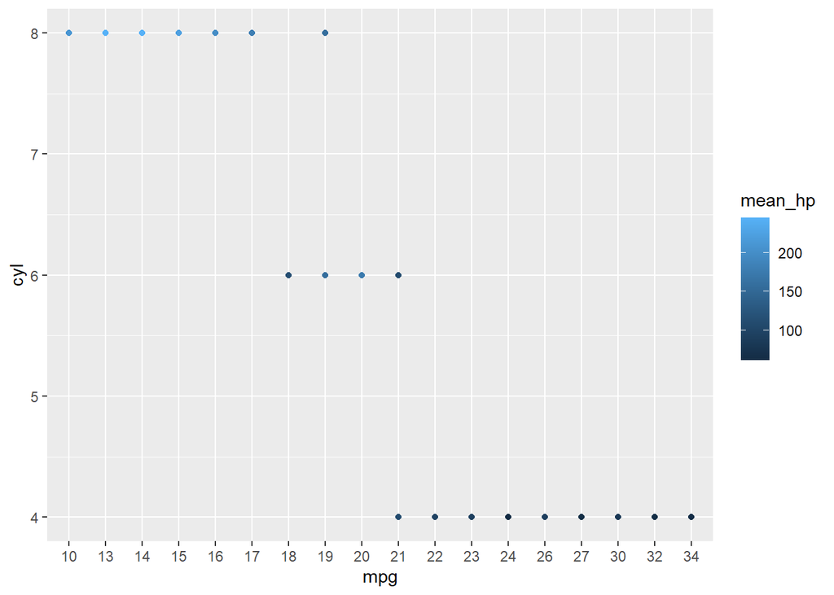

```r
library(ggplot2)
final_df %>%
  ggplot(aes(x = mpg, y = cyl, color = mean_hp)) + geom_point()
```

#### Problem Solving in R

It should be noted any function’s documentation can be brought up on the bottom right by typing ?function.  
??function will bring up all instances of it in packages installed, but not currently loaded into the environment.

```r
?as.numeric
```

```
## starting httpd help server ... done
```

```r
??as.numeric
```